# Tribushinina 2011-3 conditions

Predictions: Experiment 1 - The effect should be identical to the results reported in Tribushinina 2011, and replicated in Experiment 1a, where the small zone is bigger than the big zone in general, and also with an interaction between prototype status and size judgments, so that he big zone is bigger for prototypically small objects than for prototypically big objects and the small zone is bigger for prototypically big objects than for prototypically small objects.

Experiment 2 - The results are predicted to be the same as those for experiment 1, but the effect size may be smaller since there may be interference form the immediate context changing, though given the randomness, I do not predict this to have a large overall effect, but careful analysis (distance metric ?) may reveal an effect after all.

Eperiment 3 - The results are predicted to be the same as those for experiment 1b (reverse Tribushinina), where, since the images are larger than the real-size of the objects depicted in them, the big zone will be larger than the small zone.

The exclusion criteria for experiments 2 and 3 need modifying - lack of adjacency no longer necessarily means willful mistake, and the question is how to treat those cases in the analysis. Is it the case that lack of endpoint also may now be less damning? When should a participant be excluded?

There are two separate types of analyses - the first is the same as the analysis in Tribushinina 2011, using non-parametric statistics (Wilcoxon) to show that the difference between the big zone and the small zone is statistically significant in the direction predicted. This analysis uses a data frame in which each trial is a row. The other type of analysis is binary logistic regression. This uses a data frame in which each row represents a check box (so that each trial spans seven rows). The analysis looks at the likelihood of each checkbox being checked and asks at which box the proabblility switches to be more likely to be checked (that can be thought of as the threshold of the adjective, or the determiner of the size of the zone).

```r
###Data Preparation

####Load Relevant Libraries and Functions
library(tidyverse)
#library(langcog)
library(stringr)
library(rjson)
library(ordinal)

sem <- function(x) {sd(x, na.rm=TRUE) / sqrt(length(x))}
ci95 <- function(x) {sem(x) * 1.96}
addnas <- function (x) {if (length(x)==0){
  result = NA
} else {result = x}
  return(result)
}

# ####Import data where each row is a check box so that each trial is 7 rows.
#
# path <- "D:/Dropbox/School/more adjs/experiment 1b/Trib2011-3conditions/data/"
# files <- dir("D:/Dropbox/School/more adjs/experiment 1b/Trib2011-3conditions/data/anonymized-results/",
#              pattern = "*.json")
# d.raw.rows <- data.frame()
# NUM_PICS <- 7
#
# for (f in files) {
#   jf <- paste0(path, "anonymized-results/",f)
#   jd <- fromJSON(file = jf)
#   if (is.element(1,jd$answers$data$expt_condition)){
#     NUM_TRIALS <- 50
#   } else{
#     NUM_TRIALS <- 26
#   }
#   for (j in 1:NUM_TRIALS){
#     for(i in 1:NUM_PICS){
#     if (is.element(i, jd$answers$data$sizes[j][[1]])) {
#       is_checked <- 1
#     } else {
#       is_checked <- 0
#     }
#     id <- data.frame(subid = f,
#                    box_num = i,
#                    condition = jd$answers$data$expt_condition[j],
#                    box_checked = is_checked,
#                    ratio_prev = jd$answers$data$sizes[j-1][[1]]/jd$answers$data$sizes[j][[1]],
#                    ratio_next = jd$answers$data$sizes[j+1][[1]]/jd$answers$data$sizes[j][[1]],
#                   trial_num = j,
#                    pic_size = jd$answers$data$sizes[j][[1]],
#                    difference_from_prev = jd$answers$data$sizes[j-1][[1]]-jd$answers$data$sizes[j-][[1]],
#                    difference_from_next = jd$answers$data$sizes[j-+][[1]]-jd$answers$data$sizes[j-][[1]],
#                    adj = jd$answers$data$adj[j],
#                    verb = jd$answers$data$verb[j],
#                    dir = cbind(jd$answers$data$dir[j]),
#                    noun = jd$answers$data$noun[j],
#                    num_checked = as.numeric(jd$answers$data$num_checked[j]),
#                    elapsed_ms = jd$answers$data$elapsed_ms[j],
#                    elapsed_first_click_ms = jd$answers$data$elapsed_first_click_ms[j],
#                    workerid = jd$WorkerId,
#                    language = tolower(jd$answers$data$lang),
#                    prototype_status = jd$answers$data$prototype_status[j],
#                    non_consec = jd$answers$data$non_consecutive[j],
#                    is_endpoint = jd$answers$data$is_endpoint[j],
#                    endpoint = as.character(unlist(jd$answers$data$endpoint[j])),
#                    good_endpoint = jd$answers$data$good_ep[j],
#                    none_checked = jd$answers$data$none_checked[j],
#                    all_checked = jd$answers$data$all_checked[j],
#                    comments = jd$answers$data$expt_gen,
#                    screen_size = as.numeric(jd$answers$data$screen_size))
#
#      d.raw.rows <- bind_rows(d.raw.rows, id)
#   }
#
#
#   }
#
# }

#import data so that each row is a trial
path <- "D:/Dropbox/School/more adjs/experiment 1b/Trib2011-3conditions/data/"
files <- dir("D:/Dropbox/School/more adjs/experiment 1b/Trib2011-3conditions/data/anonymized-results/",
             pattern = "*.json")
d.raw <- data.frame()

for (f in files) {
  jf <- paste0(path, "anonymized-results/",f)
  jd <- fromJSON(file = jf)
  if (is.element(1,jd$answers$data$expt_condition)){
    NUM_TRIALS <- 50
  } else{
    NUM_TRIALS <- 26
  }
  NUM_TARGETS <- NUM_TRIALS - 2
  id <- data.frame(subid = f,
                   condition = jd$answers$data$expt_condition,
                   number_of_trials = NUM_TRIALS,
                   number_of_targets = NUM_TARGETS,
                   adj = jd$answers$data$adj,
                   verb = jd$answers$data$verb,
                   noun = jd$answers$data$noun,
                   dir = as.character(cbind(jd$answers$data$dir)),
                   num_checked = as.numeric(jd$answers$data$num_checked),
                   noun = jd$answers$data$noun,
                   elapsed_ms = jd$answers$data$elapsed_ms,
                   elapsed_first_click_ms = jd$answers$data$elapsed_first_click_ms,
                   workerid = jd$WorkerId,
                   language = tolower(jd$answers$data$lang),
                   prototype_status = jd$answers$data$prototype_status,
                   non_consec = jd$answers$data$non_consecutive,
                   is_endpoint = jd$answers$data$is_endpoint,
                   endpoint = as.character(unlist(jd$answers$data$endpoint)),
                   good_endpoint = jd$answers$data$good_ep,
                   none_checked = jd$answers$data$none_checked,
                   all_checked = jd$answers$data$all_checked,
                   comments = jd$answers$data$expt_gen,
                   screen_size = as.numeric(jd$answers$data$screen_size))


  d.raw <- bind_rows(d.raw, id)
}

#
```

Note: Manual exclusion of anon-34 due to some error in elapsed_ms where there are 27 numbers instead of 26 - must be due to some weird unidentified bug. Note: Manual exclusion of 20 duplicate participants who had already participated in either experiment 1a or 1b.

The data for these exclusions is not even read in.

```r
# Number of participants
length(unique(d.raw$workerid))
length(unique(d.raw$subid))



table(as.factor(d.raw$screen_size))
table(as.factor(d.raw$condition))
table(as.factor(d.raw$condition), as.factor(d.raw$screen_size))
table(as.factor(d.raw$condition),d.raw$language)

#### Data exclusion / filtering
```

### Cleaning up unpredicted typos

```r
table(as.factor(d.raw$language))
for (i in 1:length(d.raw$language)) {
   if (d.raw$language[i] == "rnglish" & (!is.na(d.raw$language[i]))){
   d.raw$language[i] = "english"
   }
 }
```

Analysis now precedes by condition (otherwise known as experiment). The analysis for condition one is exactly the same as that for the replication of Tribushinina 2011. The Exclusion criteria are the same (except for specific cleanup of Language typos), and the analysis is the same.

## Analysis of Condition (experiment) 1 – Replication of Tribushinina 2011 using photographs of objects instead of cartoon drawings

```r
d <- d.raw %>%
  filter(condition == 1) %>%
  filter(verb == "are") %>%
  filter(adj !="pretty") %>%
  filter(adj != "ugly")%>%
  filter(as.numeric(screen_size) >= 7) %>%
  filter(str_detect(language, 'eng')) %>%
  select(-language) %>%
  group_by(subid) %>%
  mutate(perc_non_consec = sum(non_consec)/num_trials,
            perc_no_endpoint = (length(is_endpoint)-sum(is_endpoint))/num_trials,
         perc_good_endpoint = (sum(good_endpoint))/num_trials) %>%
  filter(perc_non_consec < .1) %>%
  filter(perc_good_endpoint >.9) %>%
  filter(good_endpoint == TRUE) %>%
  filter(non_consec == FALSE) %>%
  filter(is_endpoint == TRUE)
for (i in 1:length(d$none_checked)) {
   if (d$none_checked[i] == TRUE & (!is.na(d$none_checked[i]))){
   d$num_checked[i] = 0
   }
 }
length(unique(d$workerid))
```

```
[1] 44
```

### Confirmatory analysis

#### Key test

| verb | adj | mean_zone | sds |
| --- | --- | --- | --- |
| are | big | 2.284342 | 0.8061272 |
| are | small | 3.121124 | 0.8873830 |

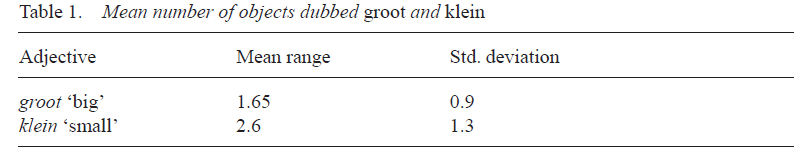

Table 1 from Tribushinina, comparing the mean number of items selected for each adjective

The **key test** compares the size of the *big* zone and the *small* zone:

```r
#The key analysis -- testing whether the small zone is bigger than the big zone
d_wilc <- d %>%
  group_by(subid, verb, noun, adj, dir) %>%
  summarise(zone = num_checked)%>%
  spread(adj, zone)
  wilcox.test(d_wilc$big, d_wilc$small, alternative = "l", paired = TRUE)
```

```
    Wilcoxon signed rank test with continuity correction

data:  d_wilc$big and d_wilc$small
V = 30548, p-value < 2.2e-16
alternative hypothesis: true location shift is less than 0
```

This experiment succeeded in replicating the key result from Tribushinina (2011). The mean number of items checked as *small* was significantly larger than the mean number of items checked as *big*.

#### Differences between items of different prototypicality status for each adjective

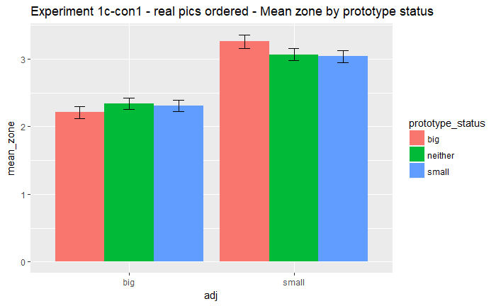

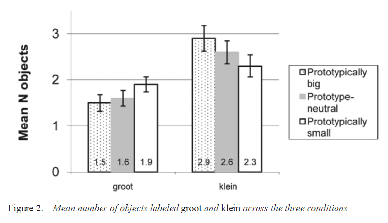

Original graph of mean number of items checked for each adjective for each prototypicality group

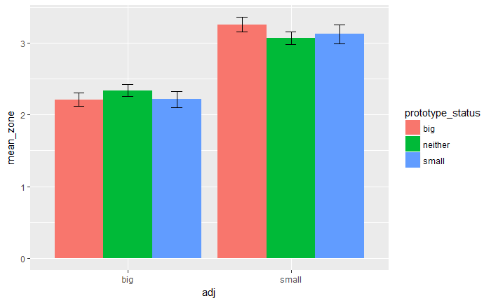

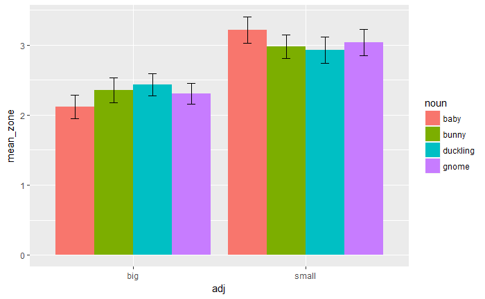

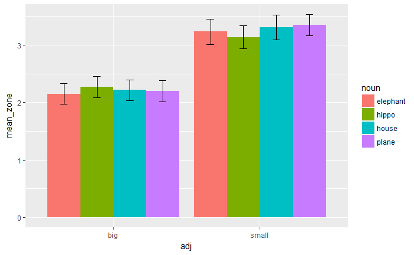

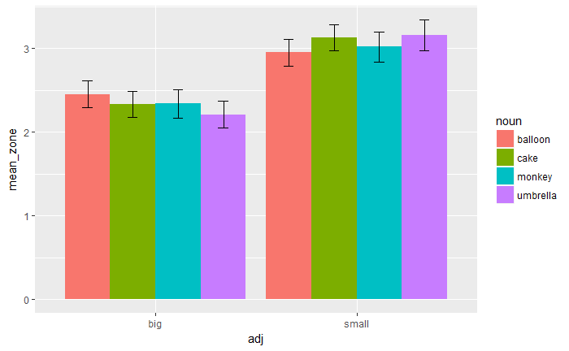

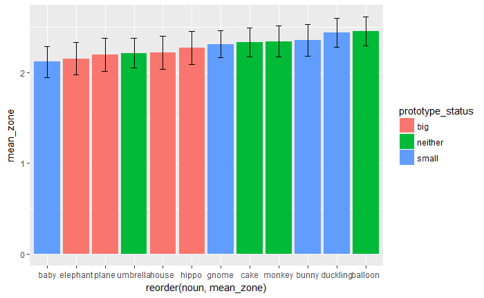

[figure not shown]

```r
# Friedman test of differences between objects of different prototypicality status when the adjective is big
d_fried <- d %>%
  filter(adj=="big")%>%
  group_by(subid, prototype_status) %>%
  summarise(zone = mean(num_checked))
```

```r
d_fried$subid <- factor(d_fried$subid)
d_fried$prototype_status <- factor(d_fried$prototype_status)
levels(d_fried$prototype_status)

#levels(d_fried$subid)
levels(d_fried$prototype_status)


friedman.test(zone ~ prototype_status  | subid, data = d_fried)
```

The Friedman test is significant at the .05 level (p=.03) showing that the *big* zone is significantly different between the three prototypicality statuses.

```r
#test the difference between prototypically big and neutral objects when the adjective is big
d_wilc_bn <- d %>%
  filter(adj == "big")%>%
  filter(prototype_status != "small")%>%
  group_by(subid, verb, prototype_status) %>%
  summarise(zone = mean(num_checked))%>%
  spread(prototype_status, zone)

wilcox.test(d_wilc_bn$big, d_wilc_bn$neither, alternative = "l", paired = TRUE)
```

the *big* zone is significantly bigger for items which are neither prototypically big nor prototypically small than it is for items which are prototypically big.

```r
#test the difference between prototypically neither and small objects when the adjective is big
d_wilc_ns <- d %>%
  filter(adj == "big")%>%
  filter(prototype_status != "big")%>%
  group_by(subid, verb, prototype_status) %>%
  summarise(zone = mean(num_checked))%>%
  spread(prototype_status, zone)

wilcox.test(d_wilc_ns$neither, d_wilc_ns$small, alternative = "l", paired = TRUE)
```

Contraray to prediction , the *big* zone is not significantly bigger for prototypically neutral items than for prototypically small items.

```r
#test the difference between prototypically big and small objects when the adjective is big
d_wilc_bs <- d %>%
  filter(adj == "big")%>%
  filter(prototype_status != "neither")%>%
  group_by(subid, verb, prototype_status) %>%
  summarise(zone = mean(num_checked))%>%
  spread(prototype_status, zone)

wilcox.test(d_wilc_bs$big, d_wilc_bs$small, alternative = "l", paired = TRUE)
```

Contraray to prediction , the *big* zone is not significantly bigger for prototypically small items than for prototypically big items.

```r
# Friedman test of differences between objects of different prototypicality status when the adjective is small
d_fried_s <- d %>%
  filter(adj=="big")%>%
  group_by(subid, prototype_status) %>%
  summarise(zone = mean(num_checked))
```

```r
d_fried_s$subid <- factor(d_fried_s$subid)
d_fried_s$prototype_status <- factor(d_fried_s$prototype_status)
levels(d_fried_s$prototype_status)

#levels(d_fried$subid)
levels(d_fried$prototype_status)


friedman.test(zone ~ prototype_status  | subid, data = d_fried_s)
```

```r
#test the difference between prototypically big and neutral objects when the adjective is small
d_wilc_sbn <- d %>%
  filter(adj == "small")%>%
  filter(prototype_status != "small")%>%
  group_by(subid, verb, prototype_status) %>%
  summarise(zone = mean(num_checked))%>%
  spread(prototype_status, zone)

wilcox.test(d_wilc_sbn$big, d_wilc_sbn$neither, alternative = "g", paired = TRUE)
```

As predicted, the *small* zone is significantly bigger for prototypically big items than for items that are neither prototypically big nor prototypically small.

```r
#test the difference between prototypically neither and small objects when the adjective is small
d_wilc_sns <- d %>%
  filter(adj == "small")%>%
  filter(prototype_status != "big")%>%
  group_by(subid, verb, prototype_status) %>%
  summarise(zone = mean(num_checked))%>%
  spread(prototype_status, zone)

wilcox.test(d_wilc_sns$neither, d_wilc_sns$small, alternative = "g", paired = TRUE)
```

```r
#test the difference between prototypically big and small objects when the adjective is small
d_wilc_sbs <- d %>%
  filter(adj == "small")%>%
  filter(prototype_status != "neither")%>%
  group_by(subid, verb, prototype_status) %>%
  summarise(zone = mean(num_checked))%>%
  spread(prototype_status, zone)

wilcox.test(d_wilc_sbs$big, d_wilc_sbs$small, alternative = "g", paired = TRUE)
```

As predicted the *small* zone is significantly bigger for prototypically big items than for prototypically small items.

## Analysis of Condition (experiment) 2 – Replication of Tribushinina 2011 using photographs of objects instead of cartoon drawings in mixed order instead of ascending/descending

```r
# look at the right condition, get rid of training items, exclude non-English speakers, exclude those described below

d <- d.raw %>%
  filter(condition == 2) %>%
  filter(verb == "are") %>%
  filter(adj !="pretty") %>%
  filter(adj != "ugly")%>%
  filter(as.numeric(screen_size) >= 7) %>%
  filter(str_detect(language, 'eng')) %>%
  select(-language) %>%
  group_by(subid) %>%
  mutate(perc_non_consec = sum(non_consec)/NUM_TARGETS,
            perc_no_endpoint = (length(is_endpoint)-sum(is_endpoint))/NUM_TARGETS,
         perc_good_endpoint = (sum(good_endpoint))/NUM_TARGETS) %>%
  filter(perc_non_consec < .1) %>%
  filter(perc_good_endpoint >.9) %>%
  filter(good_endpoint == TRUE) %>%
  filter(non_consec == FALSE) %>%
  filter(is_endpoint == TRUE)
for (i in 1:length(d$none_checked)) {
   if (d$none_checked[i] == TRUE & (!is.na(d$none_checked[i]))){
   d$num_checked[i] = 0
   }
 }

length(unique(d$workerid))
#for pilot A
# d <- filter(d.raw, prototype_status != "na") %>%
#   group_by(subid) %>%
#   mutate(perc_non_consec = sum(non_consec)/num_trials,
#             perc_no_endpoint = (length(is_endpoint)-sum(is_endpoint))/num_trials,
#          perc_good_endpoint = (sum(good_endpoint))/num_trials)

#need to check for having more than 10% non_consecutive or less than 90% with the right endpoint, and exclude those participants, and then exclude any remaining trials in which there is non_consecutive data or no endpoint.  (The option for saying none of them is big is coded as 9, so that if someone checks both the none box and one of the images then it comes up as non-consecutive)

head(d)

#### Prepare data for analysis - create columns etc.
```

Keeping the exclusion criteria the same excludes 7 subjects, which really isn’t that bad, thoughthe exclusion criteria may make less sense now that the order is mixed. The following analysis keeps the old exclusion criteria, but subsequent analyses may change this.

### Confirmatory analysis

#### Key test

| verb | adj | mean_zone | sds |
| --- | --- | --- | --- |
| are | big | 2.479711 | 0.7509281 |
| are | small | 2.883057 | 0.8021562 |

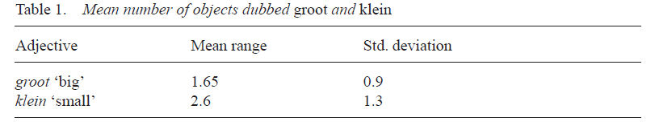

Table 1 from Tribushinina, comparing the mean number of items selected for each adjective

The **key test** compares the size of the *big* zone and the *small* zone:

```r
d_wilc <- d %>%
  group_by(subid, verb, noun, adj, dir) %>%
  summarise(zone = num_checked)%>%
  spread(adj, zone)
  wilcox.test(d_wilc$big, d_wilc$small, alternative = "l", paired = TRUE)
```

```
    Wilcoxon signed rank test with continuity correction

data:  d_wilc$big and d_wilc$small
V = 36313, p-value < 2.2e-16
alternative hypothesis: true location shift is less than 0
```

As predicted, the main effect remains, whereby the *big* zone is significantly smaller than the *small* zone, replicating the result from Tribushinina 2011.

#### Differences between items of different prototypicality status for each adjective

```r
d_graph <- d %>%
  group_by(prototype_status, adj) %>%
  summarise(mean_zone = mean(num_checked), sems = sem(num_checked), cis = ci95(num_checked))
```

[output not shown]

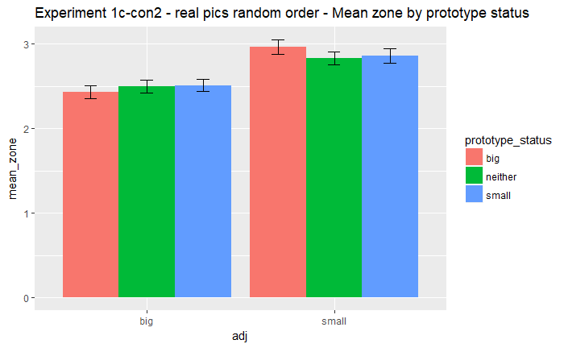

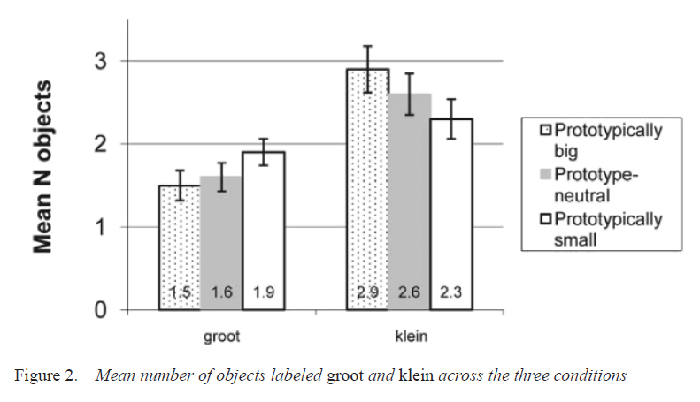

Original graph of mean number of items checked for each adjective for each prototypicality group

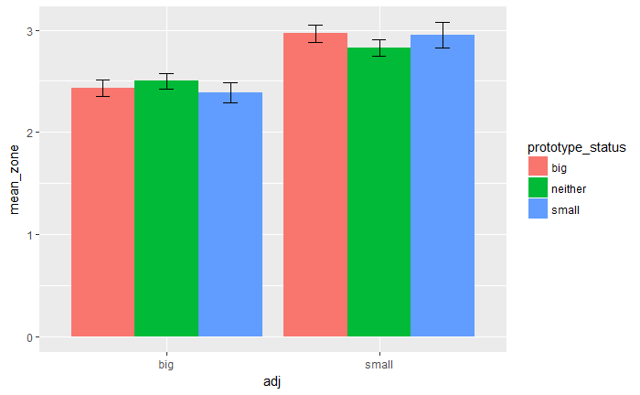

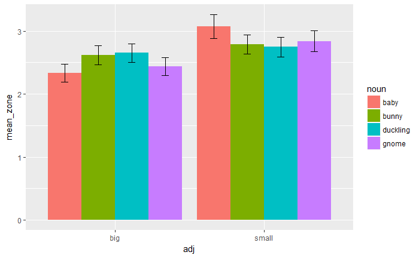

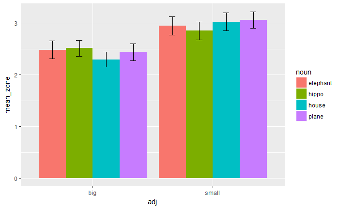

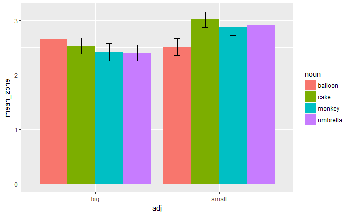

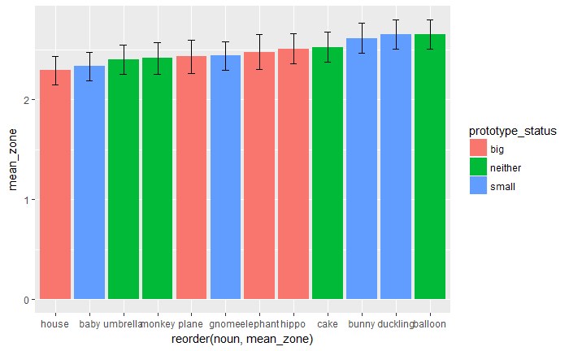

```r
by_obj_adjs <- d %>%
  filter(adj == "small")%>%
  group_by(noun)%>%
  summarise(mean_zone = mean(num_checked), sems = sem(num_checked), cis = ci95(num_checked))
#graph of mean number checked by object when the adjective is *big*

ggplot(by_obj_adjb, aes(x=reorder(noun, mean_zone), y=mean_zone)) + geom_bar(stat = "identity", position=position_dodge()) +
    geom_errorbar(aes(ymin=mean_zone-cis, ymax=mean_zone+cis),
                  width=.2, position=position_dodge(.9))
```

```r
# Friedman test of differences between objects of different prototypicality status when the adjective is big
d_fried <- d %>%
  filter(adj=="big")%>%
  group_by(subid, prototype_status) %>%
  summarise(zone = mean(num_checked))
```

```r
d_fried$subid <- factor(d_fried$subid)
d_fried$prototype_status <- factor(d_fried$prototype_status)
levels(d_fried$prototype_status)

#levels(d_fried$subid)
levels(d_fried$prototype_status)


friedman.test(zone ~ prototype_status  | subid, data = d_fried)
```

As predicted there are significant differences between the size of the *big* zone for objects of different prototypicality statuses.

```r
#test the difference between prototypically big and neutral objects when the adjective is big
d_wilc_bn <- d %>%
  filter(adj == "big")%>%
  filter(prototype_status != "small")%>%
  group_by(subid, verb, prototype_status) %>%
  summarise(zone = mean(num_checked))%>%
  spread(prototype_status, zone)

wilcox.test(d_wilc_bn$big, d_wilc_bn$neither, alternative = "l", paired = TRUE)
```

As predicted, there is a significant differnce between prototypically big items and items which are neither prototypically big nor prototypically small.

```r
#test the difference between prototypically neither and small objects when the adjective is big
d_wilc_ns <- d %>%
  filter(adj == "big")%>%
  filter(prototype_status != "big")%>%
  group_by(subid, verb, prototype_status) %>%
  summarise(zone = mean(num_checked))%>%
  spread(prototype_status, zone)

wilcox.test(d_wilc_ns$neither, d_wilc_ns$small, alternative = "l", paired = TRUE)
```

Contrary to the prediction and the finding in Tribushinina 2011, there is no significant difference between the size of the *big zone for objects that are prototypically neutral and objects that are prototypically small.

```r
#test the difference between prototypically big and small objects when the adjective is big
d_wilc_bs <- d %>%
  filter(adj == "big")%>%
  filter(prototype_status != "neither")%>%
  group_by(subid, verb, prototype_status) %>%
  summarise(zone = mean(num_checked))%>%
  spread(prototype_status, zone)

wilcox.test(d_wilc_bs$big, d_wilc_bs$small, alternative = "l", paired = TRUE)
```

```r
# Friedman test of differences between objects of different prototypicality status when the adjective is small
d_fried_s <- d %>%
  filter(adj=="big")%>%
  group_by(subid, prototype_status) %>%
  summarise(zone = mean(num_checked))
```

```r
d_fried_s$subid <- factor(d_fried_s$subid)
d_fried_s$prototype_status <- factor(d_fried_s$prototype_status)
levels(d_fried_s$prototype_status)

#levels(d_fried$subid)
levels(d_fried$prototype_status)


friedman.test(zone ~ prototype_status  | subid, data = d_fried_s)
```

```r
#test the difference between prototypically big and neutral objects when the adjective is small
d_wilc_sbn <- d %>%
  filter(adj == "small")%>%
  filter(prototype_status != "small")%>%
  group_by(subid, verb, prototype_status) %>%
  summarise(zone = mean(num_checked))%>%
  spread(prototype_status, zone)

wilcox.test(d_wilc_sbn$big, d_wilc_sbn$neither, alternative = "g", paired = TRUE)
```

As predicted, the *small* zone is significantly bigger for items that are prototypically big than for items that are neither prototypically small nor prototypically big.

```r
#test the difference between prototypically neither and small objects when the adjective is small
d_wilc_sns <- d %>%
  filter(adj == "small")%>%
  filter(prototype_status != "big")%>%
  group_by(subid, verb, prototype_status) %>%
  summarise(zone = mean(num_checked))%>%
  spread(prototype_status, zone)

wilcox.test(d_wilc_sns$neither, d_wilc_sns$small, alternative = "g", paired = TRUE)
```

Contrary to the prediction, and to the finding in Tribushinina 2011, there *small* zone is not significantly different for items that are prototypically small, and items that are neither prototypically big nor prortypically small.

```r
#test the difference between prototypically big and small objects when the adjective is small
d_wilc_sbs <- d %>%
  filter(adj == "small")%>%
  filter(prototype_status != "neither")%>%
  group_by(subid, verb, prototype_status) %>%
  summarise(zone = mean(num_checked))%>%
  spread(prototype_status, zone)

wilcox.test(d_wilc_sbs$big, d_wilc_sbs$small, alternative = "g", paired = TRUE)
```

### Discussion - Condition (experiment) 2

Overall, the main effect is still found, as predicted, wwhere the *big* zone is smaller than the *small* zone. However, the data is, not unexpectedly, messier. The overall trends within the prototypicality status distinctions are still found, though the details are not exact. The difference between the *big* zone for prototypically neutral and prototypically small items is not significant. Neither is the the difference between the *small* zone for these two categories. In other words the small and neutral objects seem to be behaving similarly. This again may possibly be due to the introduction of new small stimuli without proper piloting - the replacement of mice and chicks by bunnies and ducklings. In order to further investigate this question it is worth making the graphs excluding these two items for this experiment, for condition 1 and for experiment 1a - the direct replication of Tribushinina 2011.

## Analysis of Condition (experiment) 3 – Reverse of Tribushinina 2011 using items that are smaller than the images and in mixed order instead of ascending/descending

```r
# look at the right condition, get rid of training items, exclude non-English speakers, exclude those described below

d <- d.raw %>%
  filter(condition == 3) %>%
  filter(verb == "are") %>%
  filter(adj !="pretty") %>%
  filter(adj != "ugly")%>%
  filter(as.numeric(screen_size) >= 7) %>%
  filter(str_detect(language, 'eng')) %>%
  select(-language) %>%
  group_by(subid) %>%
  mutate(perc_non_consec = sum(non_consec)/NUM_TARGETS,
            perc_no_endpoint = (length(is_endpoint)-sum(is_endpoint))/NUM_TARGETS,
         perc_good_endpoint = (sum(good_endpoint))/NUM_TARGETS) %>%
  filter(perc_non_consec < .1) %>%
  filter(perc_good_endpoint >.9) %>%
  filter(good_endpoint == TRUE) %>%
  filter(non_consec == FALSE) %>%
  filter(is_endpoint == TRUE)
for (i in 1:length(d$none_checked)) {
   if (d$none_checked[i] == TRUE & (!is.na(d$none_checked[i]))){
   d$num_checked[i] = 0
   }
 }

length(unique(d$workerid))
#for pilot A
# d <- filter(d.raw, prototype_status != "na") %>%
#   group_by(subid) %>%
#   mutate(perc_non_consec = sum(non_consec)/num_trials,
#             perc_no_endpoint = (length(is_endpoint)-sum(is_endpoint))/num_trials,
#          perc_good_endpoint = (sum(good_endpoint))/num_trials)

#need to check for having more than 10% non_consecutive or less than 90% with the right endpoint, and exclude those participants, and then exclude any remaining trials in which there is non_consecutive data or no endpoint.  (The option for saying none of them is big is coded as 9, so that if someone checks both the none box and one of the images then it comes up as non-consecutive)

head(d)

#### Prepare data for analysis - create columns etc.
```

Again, despite the need to revisit the exclusion criteria (they are currently too harsh due to the change to mixed order), only 8 subjects are totally excluded according to the old criteria.

### Confirmatory analysis

#### Key test

| verb | adj | mean_zone | sds |
| --- | --- | --- | --- |
| are | big | 3.490368 | 1.1600243 |
| are | small | 1.964957 | 0.7326921 |

The **key test** compares the size of the *big* zone and the *small* zone:

```r
#The key analysis -- testing whether the small zone is bigger than the big zone
d_wilc <- d %>%
  group_by(subid, verb, noun, adj, dir) %>%
  summarise(zone = num_checked)%>%
  spread(adj, zone)
  wilcox.test(d_wilc$small, d_wilc$big, alternative = "l", paired = TRUE)
```

As predicted, when the items depicted are smaller than the images, the *big* zone is bigger than the *small* zone - the reverse of the results in Tribushinina 2011, experiment 1a, and conditions 1 and 2.

```r
#visualization of the data
##mean number of items checked by noun, by adjective

d.obj <- d %>%
  group_by(noun, adj) %>%
  summarize(m_zone = mean(num_checked))

d.obj
```

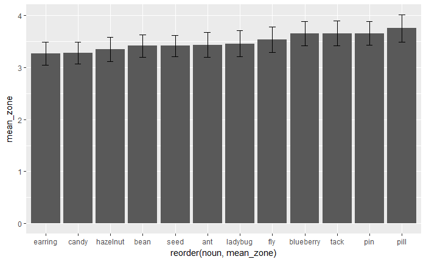

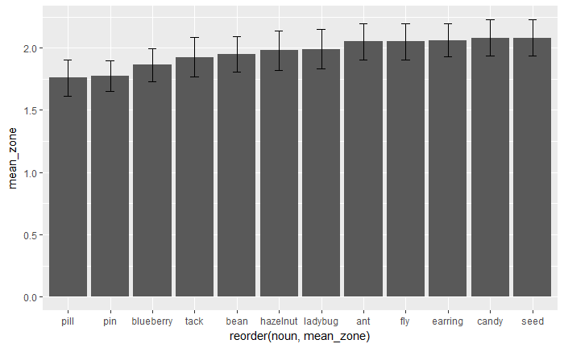